# Relacion precio medio (PM) y demanda con variables temporales (hora, dia, …)

# 2. Analisis bivarial precio medio y demanda

# Nota: este analisis cubre los apartados 2.4 y 2.5.

```r
#Nota: se utilizan las variables creadas en el fichero 1_Analisis univariable y preprocesado.Rmd
#Analisis de correlaciones entre la variable PM (Average price), hora, mes y dia
hour<-electricity_prices$Hour
t2<-data.frame(PM, electricity_prices$Hour, electricity_prices$Month, electricity_prices$dem)
names(t2)<-c("Precio Medio", "Hora", "Mes", "Demanda")
round(cor(t2), 4)
```

```
             Precio Medio   Hora     Mes Demanda
Precio Medio       1.0000 0.2378  0.3320  0.4472
Hora               0.2378 1.0000  0.0000  0.5470
Mes                0.3320 0.0000  1.0000 -0.0926
Demanda            0.4472 0.5470 -0.0926  1.0000
```

Nota: las variables hora y mes son categoricas aunque se estan utilizando como numericas

# 2.1. Analisis bivarial Precio medio, demanda y hora

# 2.1.1 PM - Hora

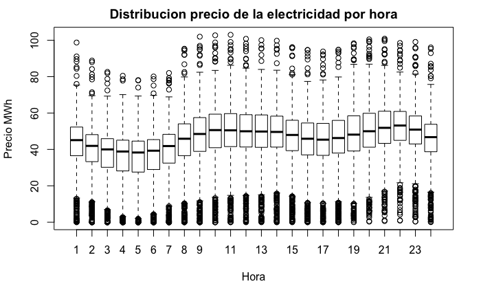

```r
#Analisis distribucion por hora
boxplot(PM~hour, main = "Distribucion precio de la electricidad por hora", xlab= "Hora", ylab= "Precio MWh")
```

```r
#Observamos las diferencias en el precio medio por hora a partir de la media
tapply(PM, hour, mean)
```

```
       1        2        3        4        5        6        7        8        9       10       11       12       13       14       15       16
43.54230 39.59744 36.89853 35.38925 34.73598 35.84542 39.51207 44.38863 47.06752 49.16017 49.55722 48.90636 48.68890 48.31234 46.36904 44.47852
      17       18       19       20       21       22       23       24
44.04088 45.43793 47.62259 49.86321 51.45233 52.21371 49.78827 45.44035
```

```r
#Calculamos la desviacion estandar por hora
tapply(PM, hour, sd)
```

```
       1        2        3        4        5        6        7        8        9       10       11       12       13       14       15       16
14.09434 13.77061 13.83363 14.03646 14.12438 13.95812 14.39472 15.45195 15.71149 15.34398 15.12004 15.01659 14.97233 15.04746 15.11700 15.52079
      17       18       19       20       21       22       23       24
15.81006 15.84712 15.63243 14.83783 13.89841 12.95127 13.14009 13.54412
```

```r
#Calculamos los valores estadisticos de media y desviacion para realizar un grafico de mean y SD
p_h<-data.frame(PM, hour)
summarySE <- function(data=NULL, measurevar, groupvars=NULL, na.rm=FALSE,
                      conf.interval=.95, .drop=TRUE) {
    library(plyr)
    # New version of length which can handle NA's: if na.rm==T, don't count them
    length2 <- function (x, na.rm=FALSE) {
        if (na.rm) sum(!is.na(x))
        else       length(x)
    }
    # This does the summary. For each group's data frame, return a vector with
    # N, mean, and sd
    datac <- ddply(data, groupvars, .drop=.drop,
      .fun = function(xx, col) {
        c(N    = length2(xx[[col]], na.rm=na.rm),
          mean = mean   (xx[[col]], na.rm=na.rm),
          sd   = sd     (xx[[col]], na.rm=na.rm)
        )
      },
      measurevar
    )
    # Rename the "mean" column
    datac <- rename(datac, c("mean" = measurevar))
    datac$se <- datac$sd / sqrt(datac$N)  # Calculate standard error of the mean
    # Confidence interval multiplier for standard error
    # Calculate t-statistic for confidence interval:
    # e.g., if conf.interval is .95, use .975 (above/below), and use df=N-1
    ciMult <- qt(conf.interval/2 + .5, datac$N-1)
    datac$ci <- datac$se * ciMult
    return(datac)
}
library(plyr)
s_hora <- summarySE(p_h, measurevar="PM", groupvars=c("hour"))
s_hora
```

| hour | N | PM | sd | se | ci |
| --- | --- | --- | --- | --- | --- |
| 1 | 1369 | 43.54230 | 14.09434 | 0.3809282 | 0.7472668 |
| 2 | 1369 | 39.59744 | 13.77061 | 0.3721786 | 0.7301026 |
| 3 | 1368 | 36.89853 | 13.83363 | 0.3740185 | 0.7337125 |
| 4 | 1369 | 35.38925 | 14.03646 | 0.3793637 | 0.7441976 |
| 5 | 1369 | 34.73598 | 14.12438 | 0.3817399 | 0.7488590 |
| 6 | 1369 | 35.84542 | 13.95812 | 0.3772464 | 0.7400441 |
| 7 | 1369 | 39.51207 | 14.39472 | 0.3890465 | 0.7631923 |
| 8 | 1369 | 44.38863 | 15.45195 | 0.4176202 | 0.8192453 |
| 9 | 1369 | 47.06752 | 15.71149 | 0.4246348 | 0.8330059 |
| 10 | 1369 | 49.16017 | 15.34398 | 0.4147023 | 0.8135213 |

[output cut: 14 more lines]

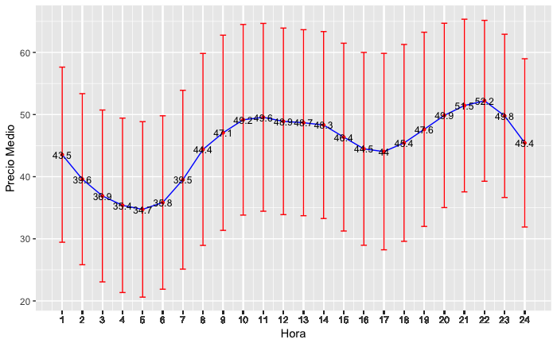

```r
#Creamos grafico de mean con standard deviation error bars
library(ggplot2)
pd <- position_dodge(0.1)
ggplot(s_hora, aes(x=hour, y=PM)) +
    geom_errorbar(aes(ymin=PM-sd, ymax=PM+sd), colour="red", width=.3, position=pd) +
    geom_line(position=pd, colour="blue") +
    xlab("Hora") +
    ylab("Precio Medio") +
    geom_point(position=pd, size=1, shape=21, color="red", fill="red") +
    geom_text(aes(label = round(PM, 1)), color="black", size=3.25)+
    scale_x_continuous(breaks=hour)
```

Referencia: http://www.cookbook-r.com/Graphs/Plotting_means_and_error_bars_(ggplot2)/

Observamos precios ligeramente mas altos entre las 8:00 y las 15:00 y en el intervalo de las 20:00 a las 22:00. En el intervalo de 20:00 a 22:00 los outliers son mas pronunciados.

# 2.1.2. Demanda - Hora

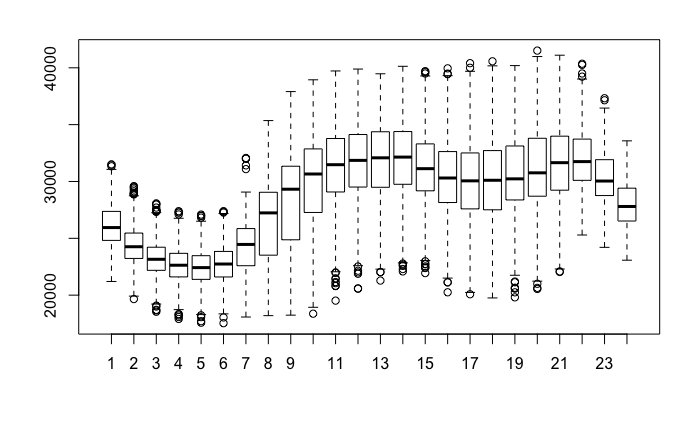

```r
#Analisis distribucion demanda por hora
boxplot(electricity_prices$dem~hour)
```

```r
#Analisis correlacion demanda - hora
cor(electricity_prices$dem, electricity_prices$Hour)
```

```
[1] 0.546953
```

La relacion entre la demanda y la hora es significativa con un valor superior al 50%.

```r
#Realizamos un grafico de medias de demanda por hora con intervalos de confianza mediante la funcion plotmeans
plotmeans(electricity_prices$dem~electricity_prices$Hour, digits=1, ccol="red", mean.labels=T,bars=T, xlab= "Hora",n.label=F, ylab= "Demanda MWh", main="Mean demanda por hora")
```

[output not shown]

```r
#Observamos las diferencias en el precio medio por hora a partir de la media
tapply(ep$dem, hour, mean)
```

```
       1        2        3        4        5        6        7        8        9       10       11       12       13       14       15       16
26061.67 24338.44 23190.26 22634.35 22418.76 22705.25 24206.19 26511.49 28407.65 30013.25 31125.04 31545.36 31752.95 31860.71 31049.04 30242.24
      17       18       19       20       21       22       23       24
29932.18 29993.21 30419.00 31023.24 31616.96 31862.56 30276.14 27940.71
```

```r
#Calculamos la desviacion estandar por hora
tapply(ep$dem, hour, sd)
```

```
       1        2        3        4        5        6        7        8        9       10       11       12       13       14       15       16
1861.688 1701.835 1594.747 1575.314 1572.223 1665.507 2279.682 3602.026 4326.427 4116.228 3781.605 3572.020 3556.950 3481.712 3259.086 3455.812
      17       18       19       20       21       22       23       24
3671.892 3801.488 3859.460 3901.622 3567.417 2806.719 2330.788 2039.429
```

La demanda mas elevada se da entre las 11:00-15:00 y las 19:00-22:00. Por el contrario, la demanda mas baja es entre las 02:00 y as 07:00.La desviacion estandar es mas elevada entre las 08:00 y las 09:00.

# 2.1.3. Precio medio por parte del dia

```r
#Creamos dummy para diferenciar dia manana, tarde y noche (morning, afternoon y night) y comprobar si existen diferencias en los grupos.
Morning<-ifelse(electricity_prices$Hour>=7&electricity_prices$Hour<13,
   1,
   0)
```

```r
Afternoon<-ifelse(electricity_prices$Hour>=13&electricity_prices$Hour<22,
   1,
   0)
```

```r
Night<-ifelse(electricity_prices$Hour>=22|electricity_prices$Hour<7,
   1,
   0)
```

```r
#Analisis correlacion morning - PM
cor(PM,Morning)
```

```
[1] 0.05582137
```

```r
#Analisis correlacion PM - tarde
cor(PM,Afternoon)
```

```
[1] 0.1213009
```

```r
#Correlacion entre PM - noche
cor(PM,Night)
```

```
[1] -0.1712321
```

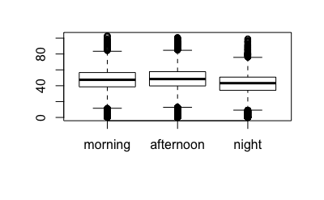

```r
Part_day<-ifelse(Night==1,
                 "night", ifelse (Morning==1,
                 "morning", "afternoon"))
Part_day<-factor(Part_day, c("morning", "afternoon", "night"))
boxplot(PM~Part_day)
```

La correlacion mas alta es con la variable noche. Esta correlacion es negativa dado que el precio medio nocturno es ligeramente mas bajo. No obstante, el valor de correlacion es muy bajo (-0.1712)

# 2.2.Analisis bivarial precio y demanda con variable dia

# 2.2.1. PM - Dia semana

```r
#Creamos nueva columna (WeekDay) convirtiendo el formato numerico de los dias (del 1 al 7) en texto
electricity_prices$WeekDay<-ifelse(electricity_prices$DayofWeek==1,
   "Lunes", ifelse(
   electricity_prices$DayofWeek==2,
   "Martes",ifelse(
   electricity_prices$DayofWeek==3,
   "Miercoles",ifelse(
   electricity_prices$DayofWeek==4,
   "Jueves",ifelse(
   electricity_prices$DayofWeek==5,
   "Viernes",ifelse(
   electricity_prices$DayofWeek==6,
   "Sabado", "Domingo"))))))
#Ordenamos dias
electricity_prices$WeekDay<-factor(electricity_prices$WeekDay, c("Lunes", "Martes", "Miercoles", "Jueves","Viernes", "Sabado", "Domingo"))
#Calculamos la media de precio por dia de la semana
tapply(PM, electricity_prices$WeekDay, mean)
```

```
    Lunes    Martes Miercoles    Jueves   Viernes    Sabado   Domingo
 46.15275  47.46439  47.33255  47.65416  47.09317  42.11881  36.66794
```

```r
#desviacion estandar por dia de la semana
tapply(PM, electricity_prices$DayofWeek, sd)
```

```
       1        2        3        4        5        6        7
15.74816 14.80356 14.62116 14.49537 15.04564 14.83116 15.85093
```

Observamos que el dia con media de precio mas alto es jueves y el dia con la media mas baja es domingo. Por otra parte, los dias con desviacion estandar mas alta son lunes y domingo (este dia el precio tiene mayor variabilidad respecto a la media). No obstante, en general las desviaciones son muy similares todos los dias de la semana.

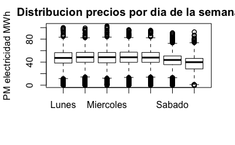

```r
#Boxplot PM por dias
boxplot(PM~electricity_prices$WeekDay, main = "Distribucion precios por dia de la semana", ylab = "PM electricidad MWh")
```